# **NLP Assignment 1**

## **NLP Group 075**

### Nareskumar P (2020FC04122),

### Kommajyosula VNS Kanth (2020FC04120),

### Tejesh Dola (2020FC04459)

*a) Download the data set and convert it in the required csv file for the computation. Perform pre-processing steps by Removing Twitter Handles (@user), Removing Punctuations, Numbers, and Special Characters, Removing Short Words in dataset.*

## Importing Libraries and reading data

```python
#importing libraries
import re # for regular expressions
import pandas as pd
pd.set_option("display.max_colwidth", 200)
import numpy as np
import matplotlib.pyplot as plt
import seaborn as sns
import string
import nltk # for text manipulation
import warnings
warnings.filterwarnings("ignore", category=DeprecationWarning)
from google.colab import drive

%matplotlib inline
```

```python
#Reading train and test dataset
drive.mount('/content/gdrive')
root_path = 'gdrive/My Drive/'
train_dataset= pd.read_csv('gdrive/My Drive/train_dataset.csv', encoding='latin-1')
test_dataset= pd.read_csv('gdrive/My Drive/test_dataset.csv', encoding='latin-1')
```

```python
train_dataset.head()
```

|  | id | label | tweet |
| --- | --- | --- | --- |
| 0 | 1 | 0 | @user when a father is dysfunctional and is so selfish he drags his kids into his dysfunction. #run |
| 1 | 2 | 0 | @user @user thanks for #lyft credit i can't use cause they don't offer wheelchair vans in pdx. #disapointed #getthanked |
| 2 | 3 | 0 | bihday your majesty |
| 3 | 4 | 0 | #model i love u take with u all the time in urð±!!! ððððÂ ð¦ð¦ð¦ |
| 4 | 5 | 0 | factsguide: society now #motivation |

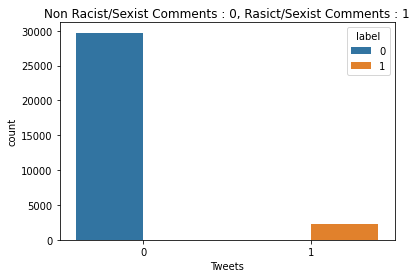

```python
#Checking the count of both bad and good comments
sns.countplot(data=train_dataset, x='label', hue='label')
plt.title('Non Racist/Sexist Comments : 0, Rasict/Sexist Comments : 1')
plt.xlabel('Tweets')
plt.show()
```

```python
train_dataset['label'].value_counts()
```

```
0    29720
1     2242
Name: label, dtype: int64
```

## Text Cleaning and Preprocessing

```python
#Checking non racist/sexist tweets
train_dataset[train_dataset['label'] == 0].head(10)
```

|  | id | label | tweet |
| --- | --- | --- | --- |
| 0 | 1 | 0 | @user when a father is dysfunctional and is so selfish he drags his kids into his dysfunction. #run |
| 1 | 2 | 0 | @user @user thanks for #lyft credit i can't use cause they don't offer wheelchair vans in pdx. #disapointed #getthanked |
| 2 | 3 | 0 | bihday your majesty |
| 3 | 4 | 0 | #model i love u take with u all the time in urð±!!! ððððÂ ð¦ð¦ð¦ |
| 4 | 5 | 0 | factsguide: society now #motivation |
| 5 | 6 | 0 | [2/2] huge fan fare and big talking before they leave. chaos and pay disputes when they get there. #allshowandnogo |
| 6 | 7 | 0 | @user camping tomorrow @user @user @user @user @user @user @user dannyâ¦ |
| 7 | 8 | 0 | the next school year is the year for exams.ð¯ can't think about that ð #school #exams #hate #imagine #actorslife #revolutionschool #girl |
| 8 | 9 | 0 | we won!!! love the land!!! #allin #cavs #champions #cleveland #clevelandcavaliers â¦ |
| 9 | 10 | 0 | @user @user welcome here ! i'm it's so #gr8 ! |

```python
#Checking racist/sexist tweets
train_dataset[train_dataset['label'] == 1].head(10)
```

|  | id | label | tweet |
| --- | --- | --- | --- |
| 13 | 14 | 1 | @user #cnn calls #michigan middle school 'build the wall' chant '' #tcot |
| 14 | 15 | 1 | no comment! in #australia #opkillingbay #seashepherd #helpcovedolphins #thecove #helpcovedolphins |
| 17 | 18 | 1 | retweet if you agree! |
| 23 | 24 | 1 | @user @user lumpy says i am a . prove it lumpy. |
| 34 | 35 | 1 | it's unbelievable that in the 21st century we'd need something like this. again. #neverump #xenophobia |
| 56 | 57 | 1 | @user lets fight against #love #peace |
| 68 | 69 | 1 | ð©the white establishment can't have blk folx running around loving themselves and promoting our greatness |
| 77 | 78 | 1 | @user hey, white people: you can call people 'white' by @user #race #identity #medâ¦ |
| 82 | 83 | 1 | how the #altright uses &amp; insecurity to lure men into #whitesupremacy |
| 111 | 112 | 1 | @user i'm not interested in a #linguistics that doesn't address #race &amp; . racism is about #power. #raciolinguistics bringsâ¦ |

```python
train_dataset.shape, test_dataset.shape
```

```
((31962, 3), (17197, 2))
```

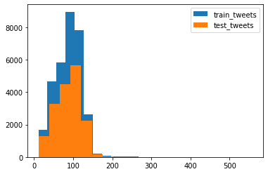

```python
#Checking the distribution of length of the tweets, in terms of words, in both train and test data.
train_len = train_dataset['tweet'].str.len()
test_len = test_dataset['tweet'].str.len()

plt.hist(train_len, bins=20, label="train_tweets")
plt.hist(test_len, bins=20, label="test_tweets")
plt.legend()
plt.show()
```

```python
merge_df = train_dataset.append(test_dataset, ignore_index=True)
merge_df.shape
```

```
(49159, 3)
```

**Data Cleaning**

```python
def pattern_remove(text, pattern):
    r = re.findall(pattern, text)
    for i in r:
        text = re.sub(i, '', text)

    return text
```

**Remove @User**

```python
merge_df['clean_tweet'] = np.vectorize(pattern_remove)(merge_df['tweet'], "@[\w]*")
```

```python
merge_df.head()
```

|  | id | label | tweet | clean_tweet |
| --- | --- | --- | --- | --- |
| 0 | 1 | 0.0 | @user when a father is dysfunctional and is so selfish he drags his kids into his dysfunction. #run | when a father is dysfunctional and is so selfish he drags his kids into his dysfunction. #run |
| 1 | 2 | 0.0 | @user @user thanks for #lyft credit i can't use cause they don't offer wheelchair vans in pdx. #disapointed #getthanked | thanks for #lyft credit i can't use cause they don't offer wheelchair vans in pdx. #disapointed #getthanked |
| 2 | 3 | 0.0 | bihday your majesty | bihday your majesty |
| 3 | 4 | 0.0 | #model i love u take with u all the time in urð±!!! ððððÂ ð¦ð¦ð¦ | #model i love u take with u all the time in urð±!!! ððððÂ ð¦ð¦ð¦ |
| 4 | 5 | 0.0 | factsguide: society now #motivation | factsguide: society now #motivation |

**Removing Punctuations, Numbers, and Special Characters**

```python
merge_df['clean_tweet'] = merge_df['clean_tweet'].str.replace("[^a-zA-Z#]", " ")
```

```python
merge_df.head(10)
```

|  | id | label | tweet | clean_tweet |
| --- | --- | --- | --- | --- |
| 0 | 1 | 0.0 | @user when a father is dysfunctional and is so selfish he drags his kids into his dysfunction. #run | when a father is dysfunctional and is so selfish he drags his kids into his dysfunction #run |
| 1 | 2 | 0.0 | @user @user thanks for #lyft credit i can't use cause they don't offer wheelchair vans in pdx. #disapointed #getthanked | thanks for #lyft credit i can t use cause they don t offer wheelchair vans in pdx #disapointed #getthanked |
| 2 | 3 | 0.0 | bihday your majesty | bihday your majesty |
| 3 | 4 | 0.0 | #model i love u take with u all the time in urð±!!! ððððÂ ð¦ð¦ð¦ | #model i love u take with u all the time in ur |
| 4 | 5 | 0.0 | factsguide: society now #motivation | factsguide society now #motivation |
| 5 | 6 | 0.0 | [2/2] huge fan fare and big talking before they leave. chaos and pay disputes when they get there. #allshowandnogo | huge fan fare and big talking before they leave chaos and pay disputes when they get there #allshowandnogo |
| 6 | 7 | 0.0 | @user camping tomorrow @user @user @user @user @user @user @user dannyâ¦ | camping tomorrow danny |
| 7 | 8 | 0.0 | the next school year is the year for exams.ð¯ can't think about that ð #school #exams #hate #imagine #actorslife #revolutionschool #girl | the next school year is the year for exams can t think about that #school #exams #hate #imagine #actorslife #revolutionschool #girl |
| 8 | 9 | 0.0 | we won!!! love the land!!! #allin #cavs #champions #cleveland #clevelandcavaliers â¦ | we won love the land #allin #cavs #champions #cleveland #clevelandcavaliers |
| 9 | 10 | 0.0 | @user @user welcome here ! i'm it's so #gr8 ! | welcome here i m it s so #gr |

**Removing Short Words**

```python
merge_df['clean_tweet'] = merge_df['clean_tweet'].apply(lambda x: ' '.join([w for w in x.split() if len(w)>3]))
```

**Text Normalization**

```python
tokenized_tweet = merge_df['clean_tweet'].apply(lambda x: x.split()) # tokenizing
```

```python
tokenized_tweet.head()
```

```
0                [when, father, dysfunctional, selfish, drags, kids, into, dysfunction, #run]
1    [thanks, #lyft, credit, cause, they, offer, wheelchair, vans, #disapointed, #getthanked]
2                                                                     [bihday, your, majesty]
3                                                            [#model, love, take, with, time]
4                                                          [factsguide, society, #motivation]
Name: clean_tweet, dtype: object
```

```python
from nltk.stem.porter import *
stemmer = PorterStemmer()

tokenized_tweet = tokenized_tweet.apply(lambda x: [stemmer.stem(i) for i in x]) # stemming
```

```python
for i in range(len(tokenized_tweet)):
    tokenized_tweet[i] = ' '.join(tokenized_tweet[i])

merge_df['clean_tweet'] = tokenized_tweet
```

## Data Visualization

**Common words cloud**

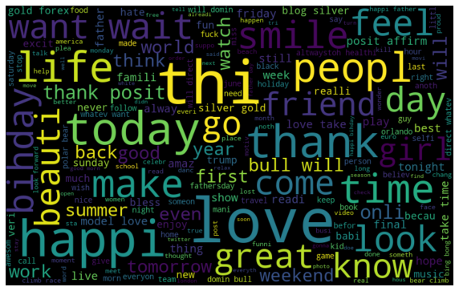

```python
words = ' '.join([text for text in merge_df['clean_tweet']])
from wordcloud import WordCloud
wordcloud = WordCloud(width=800, height=500, random_state=21, max_font_size=110).generate(words)

plt.figure(figsize=(10, 7))
plt.imshow(wordcloud, interpolation="bilinear")
plt.axis('off')
plt.show()
```

*c)Plot two different word clouds “Words in non racist/sexist tweets” and “Words in racist/sexist tweets” and understand the impact of Hashtags on tweets*

**Non Racist/Sexist words cloud**

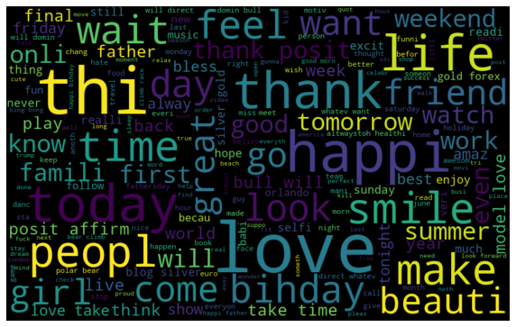

```python
good_words =' '.join([text for text in merge_df['clean_tweet'][merge_df['label'] == 0]])

wordcloud = WordCloud(width=800, height=500, random_state=21, max_font_size=110).generate(good_words)
plt.figure(figsize=(10, 7))
plt.imshow(wordcloud, interpolation="bilinear")
plt.axis('off')
plt.show()
```

**Racist/Sexist words cloud**

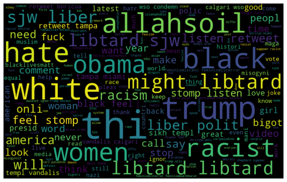

```python
bad_words = ' '.join([text for text in merge_df['clean_tweet'][merge_df['label'] == 1]])
wordcloud = WordCloud(width=800, height=500,random_state=21, max_font_size=110).generate(bad_words)
plt.figure(figsize=(10, 7))
plt.imshow(wordcloud, interpolation="bilinear")
plt.axis('off')
plt.show()
```

**Impact of Hashtags on tweets sentiment**

```python
# function to collect hashtags
def hashtag_extract(x):
    hashtags = []
    # Loop over the words in the tweet
    for i in x:
        ht = re.findall(r"#(\w+)", i)
        hashtags.append(ht)

    return hashtags
```

```python
# extracting hashtags from non racist/sexist tweets

HT_regular = hashtag_extract(merge_df['clean_tweet'][merge_df['label'] == 0])

# extracting hashtags from racist/sexist tweets
HT_negative = hashtag_extract(merge_df['clean_tweet'][merge_df['label'] == 1])

# unnesting list
HT_regular = sum(HT_regular,[])
HT_negative = sum(HT_negative,[])
```

**Non Racist/Sexist words**

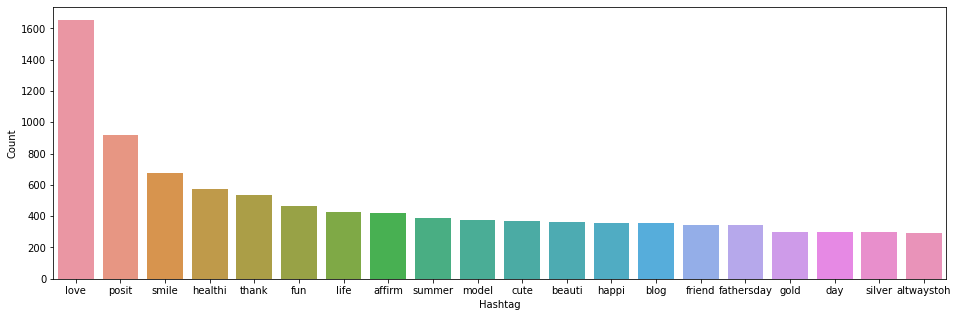

```python
a = nltk.FreqDist(HT_regular)
d = pd.DataFrame({'Hashtag': list(a.keys()),
                  'Count': list(a.values())})

# selecting top 20 most frequent hashtags
d = d.nlargest(columns="Count", n = 20)
plt.figure(figsize=(16,5))
ax = sns.barplot(data=d, x= "Hashtag", y = "Count")
ax.set(ylabel = 'Count')
plt.show()
```

**Racist/Sexist words**

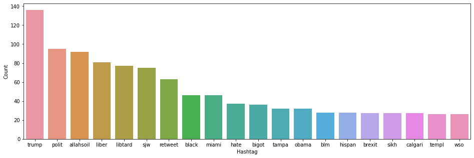

```python
b = nltk.FreqDist(HT_negative)
e = pd.DataFrame({'Hashtag': list(b.keys()), 'Count': list(b.values())})

# selecting top 20 most frequent hashtags
e = e.nlargest(columns="Count", n = 20)
plt.figure(figsize=(16,5))
ax = sns.barplot(data=e, x= "Hashtag", y = "Count")
```

*d)Extract Features from Cleaned Tweets like Bag-of-Words Features, TF-IDF Features, Word Embeddings*

### Extracting Features from Cleaned Tweets

```python
from sklearn.feature_extraction.text import TfidfVectorizer, CountVectorizer
import gensim
```

**Bag-of-Words Features**

```python
bow_vectorizer = CountVectorizer(max_df=0.90, min_df=2, max_features=1000, stop_words='english')
bow = bow_vectorizer.fit_transform(merge_df['clean_tweet'])
bow.shape
```

```
(49159, 1000)
```

**TF-IDF Features**

```python
tfidf_vectorizer = TfidfVectorizer(max_df=0.90, min_df=2, max_features=1000, stop_words='english')
tfidf = tfidf_vectorizer.fit_transform(merge_df['clean_tweet'])
tfidf.shape
```

```
(49159, 1000)
```

**Word Embeddings**

**1. Word2Vec Embeddings**

```python
tokenized_tweet = merge_df['clean_tweet'].apply(lambda x: x.split()) # tokenizing

model_w2v = gensim.models.Word2Vec(
            tokenized_tweet,
            size=200, # desired no. of features/independent variables
            window=5, # context window size
            min_count=2,
            sg = 1, # 1 for skip-gram model
            hs = 0,
            negative = 10, # for negative sampling
            workers= 2, # no.of cores
            seed = 34)

model_w2v.train(tokenized_tweet, total_examples= len(merge_df['clean_tweet']), epochs=20)
```

```
(6510286, 7536020)
```

```python
model_w2v.wv.most_similar(positive="dinner")
```

```
[('#cellar', 0.5579977035522461),
 ('spaghetti', 0.5512894988059998),
 ('noodl', 0.5495744347572327),
 ('dess', 0.5431200265884399),
 ('kayak', 0.5392516851425171),
 ('aladdin', 0.5386977195739746),
 ('spinach', 0.5380656719207764),
 ('#foodcoma', 0.5376062393188477),
 ('lukey', 0.5363965034484863),
 ('#tacotuesday', 0.5356424450874329)]
```

```python
model_w2v.wv.most_similar(positive="trump")
```

```
[('donald', 0.5632095336914062),
 ('unfit', 0.5328583121299744),
 ('#delegaterevolt', 0.5326083898544312),
 ('phoni', 0.5315040349960327),
 ('nomine', 0.5295523405075073),
 ('melo', 0.5293089747428894),
 ('tomlin', 0.5178320407867432),
 ('unfavor', 0.5159081220626831),
 ('unstabl', 0.5154194831848145),
 ('jibe', 0.5139707922935486)]
```

```python
model_w2v['food']
```

```
array([-4.82707411e-01,  2.15325542e-02,  5.13401151e-01,  7.58479536e-02,
       -4.60382313e-01,  1.89015031e-01,  7.37096906e-01, -2.02934101e-01,
        4.31684107e-01,  2.84098178e-01, -3.56609434e-01, -6.48778677e-01,
       -3.18271399e-01, -1.80566326e-01,  8.30829740e-01, -4.09540147e-01,
        4.22244161e-01,  8.87985602e-02, -6.14736438e-01,  1.67188406e-01,
        2.76207417e-01, -6.68212295e-01,  7.01958716e-01,  1.79961309e-01,
       -6.03848815e-01,  4.42397326e-01, -6.73370540e-01, -1.57101780e-01,
        3.84515256e-01, -6.43023729e-01, -2.78374374e-01, -3.77503037e-01,
        7.60774389e-02, -1.79279238e-01,  4.46335793e-01,  5.40198207e-01,
       -4.15317684e-01,  4.13738310e-01, -3.45553726e-01, -1.61312982e-01,
       -1.32103907e-02,  3.34751070e-01,  1.81225538e-01, -6.35177612e-01,
       -6.67889237e-01,  8.69425774e-01, -7.80689046e-02,  9.49530527e-02,
        4.10582696e-04, -1.43707052e-01, -5.67982674e-01, -3.63009274e-01,
        2.68590767e-02, -1.61518857e-01, -1.60071999e-02, -1.49442464e-01,
       -4.05259401e-01, -3.53453904e-01, -6.02765560e-01,  3.40336472e-01,
       -2.20330283e-01, -1.20778354e-02, -7.64855444e-01,  8.18913132e-02,
       -7.53298551e-02, -8.54934379e-02, -5.49786389e-01,  7.47578859e-01,
        1.48077160e-01, -7.23499715e-01,  1.31745845e-01,  4.37675528e-02,
        1.33459836e-01,  3.81643832e-01, -2.62197107e-01, -2.16435447e-01,
       -2.98024528e-02, -3.69679749e-01, -3.06633741e-01, -5.09470880e-01,
       -5.49713731e-01, -1.64142951e-01, -9.11506355e-01,  3.73100936e-01,
       -8.33233595e-01,  4.05723989e-01,  7.18244612e-01,  1.72848433e-01,
        5.02564609e-01,  2.77416468e-01, -8.09203163e-02,  3.63362312e-01,
        7.91231871e-01,  3.51294056e-02, -2.23399252e-01,  1.01944255e-02,
       -7.54492879e-01, -6.88182982e-03, -5.69566250e-01,  9.53968242e-03,
       -4.82148141e-01, -9.31520462e-02,  8.93369615e-01,  3.61132890e-01,
       -3.31878901e-01, -5.79616129e-01,  6.37415648e-01, -3.20455164e-01,
       -1.05965948e+00, -5.18448427e-02, -2.28221893e-01, -5.67479134e-02,
       -1.27741441e-01,  8.60293508e-02, -2.42962688e-01, -1.10374856e+00,
        4.13850874e-01,  3.32144648e-01, -2.61055566e-02,  5.68665005e-02,
       -8.20129961e-02,  2.92677969e-01, -4.78666238e-02, -1.26452625e-01,
        4.04561192e-01, -5.62950850e-01,  9.57444012e-01,  6.03982806e-01,
        3.91506851e-01,  5.99928349e-02,  1.39131695e-01,  3.20541680e-01,
        6.69691443e-01,  2.86615729e-01, -7.21003413e-02, -1.62852928e-02,
        2.61007428e-01,  6.55299008e-01, -2.78096169e-01, -4.74047035e-01,
       -5.25263667e-01, -2.04496026e-01,  9.45460975e-01, -1.38958907e+00,
       -1.00279264e-01,  7.30502605e-02, -2.39195287e-01,  3.10073107e-01,
        1.01471901e+00, -5.72355799e-02,  1.38757110e-01,  3.81079018e-01,
        9.05283868e-01,  2.43328169e-01, -1.78466260e-01, -2.91133765e-02,
       -6.38102055e-01,  1.00450926e-01, -1.57767326e-01,  5.81109710e-02,
       -3.59691769e-01, -3.02067697e-01, -1.31352916e-01, -1.71713606e-01,
       -8.50811779e-01, -7.48179913e-01, -1.47772729e-01,  2.43256629e-01,
        2.24668816e-01,  5.59922099e-01, -4.47462574e-02,  4.86426443e-01,
       -8.03352594e-02,  1.47707388e-01, -3.67476732e-01,  6.89442456e-01,
       -5.87973475e-01, -3.44075918e-01,  4.89677638e-01,  3.82761031e-01,
        3.91714782e-01,  2.47138128e-01,  2.47145936e-01,  4.60221887e-01,
       -3.77053827e-01,  1.81768864e-01,  1.54476345e-01, -8.12484920e-01,
       -2.02626422e-01,  6.38363719e-01, -2.35508084e-02,  7.16771781e-02,
        1.64098099e-01, -1.96298957e-01, -3.72121602e-01,  6.13617823e-02,
        2.58582354e-01, -1.12678900e-01, -4.75955248e-01, -3.97091001e-01],
      dtype=float32)
```

```python
len(model_w2v['food'])
```

```
200
```

**Preparing Vectors for Tweets**

```python
def word_vector(tokens, size):
    vec = np.zeros(size).reshape((1, size))
    count = 0.
    for word in tokens:
        try:
            vec += model_w2v[word].reshape((1, size))
            count += 1.
        except KeyError: # handling the case where the token is not in vocabulary

            continue
    if count != 0:
        vec /= count
    return vec
```

```python
wordvec_arrays = np.zeros((len(tokenized_tweet), 200))

for i in range(len(tokenized_tweet)):
    wordvec_arrays[i,:] = word_vector(tokenized_tweet[i], 200)

wordvec_df = pd.DataFrame(wordvec_arrays)
wordvec_df.shape
```

```
(49159, 200)
```

**2. Doc2Vec Embedding**

```python
from tqdm import tqdm
tqdm.pandas(desc="progress-bar")
from gensim.models.doc2vec import LabeledSentence
```

```python
def add_label(twt):
    output = []
    for i, s in zip(twt.index, twt):
        output.append(LabeledSentence(s, ["tweet_" + str(i)]))
    return output
```

```python
labeled_tweets = add_label(tokenized_tweet) # label all the tweets
```

```python
labeled_tweets[:6]
```

```
[LabeledSentence(words=['when', 'father', 'dysfunct', 'selfish', 'drag', 'kid', 'into', 'dysfunct', '#run'], tags=['tweet_0']),
 LabeledSentence(words=['thank', '#lyft', 'credit', 'caus', 'they', 'offer', 'wheelchair', 'van', '#disapoint', '#getthank'], tags=['tweet_1']),
 LabeledSentence(words=['bihday', 'your', 'majesti'], tags=['tweet_2']),
 LabeledSentence(words=['#model', 'love', 'take', 'with', 'time'], tags=['tweet_3']),
 LabeledSentence(words=['factsguid', 'societi', '#motiv'], tags=['tweet_4']),
 LabeledSentence(words=['huge', 'fare', 'talk', 'befor', 'they', 'leav', 'chao', 'disput', 'when', 'they', 'there', '#allshowandnogo'], tags=['tweet_5'])]
```

```python
model_d2v = gensim.models.Doc2Vec(dm=1, # dm = 1 for ‘distributed memory’ model
                                  dm_mean=1, # dm = 1 for using mean of the context word vectors
                                  size=200, # no. of desired features
                                  window=5, # width of the context window
                                  negative=7, # if > 0 then negative sampling will be used
                                  min_count=5, # Ignores all words with total frequency lower than 2.
                                  workers=3, # no. of cores
                                  alpha=0.1, # learning rate
                                  seed = 23)

model_d2v.build_vocab([i for i in tqdm(labeled_tweets)])
```

```python
model_d2v.train(labeled_tweets, total_examples= len(merge_df['clean_tweet']), epochs=15)
```

```python
docvec_arrays = np.zeros((len(tokenized_tweet), 200))

for i in range(len(merge_df)):
    docvec_arrays[i,:] = model_d2v.docvecs[i].reshape((1,200))

docvec_df = pd.DataFrame(docvec_arrays)
docvec_df.shape
```

```
(49159, 200)
```

*e)Build the classification model using Bag-of-Words, TF-IDF, word2vec vectors, and doc2vec vectors*

All the pre-modeling stages required to get the data in the proper form and shape are done. We will be building models on the datasets with different feature sets prepared in the earlier sections — Bag-of-Words, TF-IDF, word2vec vectors, and doc2vec vectors. We will use the following algorithms to build models:

Logistic Regression

XGBoost

RandomForest

## Model Building

**1. Logistic Regression**

```python
from sklearn.linear_model import LogisticRegression
from sklearn.model_selection import train_test_split
from sklearn.metrics import f1_score
```

**Bag-of-Words Features**

```python
train_bow = bow[:31962,:]
test_bow = bow[31962:,:]

# splitting data into training and validation set
xtrain_bow, xvalid_bow, ytrain, yvalid = train_test_split(train_bow, train_dataset['label'],
                                                          random_state=42,
                                                          test_size=0.3)
```

```python
lreg = LogisticRegression()
lreg.fit(xtrain_bow, ytrain) # training the model

prediction = lreg.predict_proba(xvalid_bow) # predicting on the validation set
prediction_int = prediction[:,1] >= 0.3 # if prediction is greater than or equal to 0.3 than 1 else 0
prediction_int = prediction_int.astype(np.int)

f1_score(yvalid, prediction_int) # calculating f1 score
```

```
0.5303408146300915
```

```python
test_pred = lreg.predict_proba(test_bow)
test_pred_int = test_pred[:,1] >= 0.3
test_pred_int = test_pred_int.astype(np.int)
test_dataset['label'] = test_pred_int
```

```python
submission = test_dataset[['id','label']]
submission.head()
```

|  | id | label |
| --- | --- | --- |
| 0 | 31963 | 0 |
| 1 | 31964 | 0 |
| 2 | 31965 | 0 |
| 3 | 31966 | 0 |
| 4 | 31967 | 0 |

**TF-IDF Features**

```python
train_tfidf = tfidf[:31962,:]
test_tfidf = tfidf[31962:,:]

xtrain_tfidf = train_tfidf[ytrain.index]
xvalid_tfidf = train_tfidf[yvalid.index]
```

```python
lreg.fit(xtrain_tfidf, ytrain)

prediction = lreg.predict_proba(xvalid_tfidf)
prediction_int = prediction[:,1] >= 0.3
prediction_int = prediction_int.astype(np.int)

f1_score(yvalid, prediction_int)
```

```
0.5451327433628319
```

**Word2Vec Features**

```python
train_w2v = wordvec_df.iloc[:31962,:]
test_w2v = wordvec_df.iloc[31962:,:]

xtrain_w2v = train_w2v.iloc[ytrain.index,:]
xvalid_w2v = train_w2v.iloc[yvalid.index,:]
```

```python
lreg.fit(xtrain_w2v, ytrain)

prediction = lreg.predict_proba(xvalid_w2v)
prediction_int = prediction[:,1] >= 0.3
prediction_int = prediction_int.astype(np.int)
f1_score(yvalid, prediction_int)
```

```
0.6331360946745563
```

**Doc2Vec Features**

```python
train_d2v = docvec_df.iloc[:31962,:]
test_d2v = docvec_df.iloc[31962:,:]

xtrain_d2v = train_d2v.iloc[ytrain.index,:]
xvalid_d2v = train_d2v.iloc[yvalid.index,:]
```

```python
lreg.fit(xtrain_d2v, ytrain)

prediction = lreg.predict_proba(xvalid_d2v)
prediction_int = prediction[:,1] >= 0.3
prediction_int = prediction_int.astype(np.int)
f1_score(yvalid, prediction_int)
```

```
0.3865401207937877
```

**2. XGBoost**

```python
from xgboost import XGBClassifier
```

**Bag-of-Words Features**

```python
xgb_model = XGBClassifier(max_depth=6, n_estimators=1000).fit(xtrain_bow, ytrain)
prediction = xgb_model.predict(xvalid_bow)
f1_score(yvalid, prediction)
```

```
0.5130687318489837
```

```python
test_pred = xgb_model.predict(test_bow)
test_dataset['label'] = test_pred
submission = test_dataset[['id','label']]
submission.head()
```

|  | id | label |
| --- | --- | --- |
| 0 | 31963 | 0 |
| 1 | 31964 | 0 |
| 2 | 31965 | 0 |
| 3 | 31966 | 0 |
| 4 | 31967 | 0 |

**TF-IDF Features**

```python
xgb = XGBClassifier(max_depth=6, n_estimators=1000).fit(xtrain_tfidf, ytrain)

prediction = xgb.predict(xvalid_tfidf)
f1_score(yvalid, prediction)
```

```
0.5185891325071497
```

**Word2Vec Features**

```python
xgb = XGBClassifier(max_depth=6, n_estimators=1000, nthread= 3).fit(xtrain_w2v, ytrain)
prediction = xgb.predict(xvalid_w2v)
f1_score(yvalid, prediction)
```

```
0.6386861313868614
```

**Doc2Vec Features**

```python
xgb = XGBClassifier(max_depth=6, n_estimators=1000, nthread= 3).fit(xtrain_d2v, ytrain)
prediction = xgb.predict(xvalid_d2v)
f1_score(yvalid, prediction)
```

```
0.3565022421524664
```

**3. RandomForest**

```python
from sklearn.ensemble import RandomForestClassifier
```

**Bag-of-Words Features**

```python
rf = RandomForestClassifier(n_estimators=400, random_state=11).fit(xtrain_bow, ytrain)

prediction = rf.predict(xvalid_bow)
f1_score(yvalid, prediction)
```

```
0.5529225908372828
```

```python
test_pred = rf.predict(test_bow)
test_dataset['label'] = test_pred
submission = test_dataset[['id','label']]
submission.head()
```

|  | id | label |
| --- | --- | --- |
| 0 | 31963 | 0 |
| 1 | 31964 | 1 |
| 2 | 31965 | 0 |
| 3 | 31966 | 0 |
| 4 | 31967 | 0 |

**TF-IDF Features**

```python
rf = RandomForestClassifier(n_estimators=400, random_state=11).fit(xtrain_tfidf, ytrain)

prediction = rf.predict(xvalid_tfidf)
f1_score(yvalid, prediction)
```

```
0.562152133580705
```

**Word2Vec Features**

```python
rf = RandomForestClassifier(n_estimators=400, random_state=11).fit(xtrain_w2v, ytrain)

prediction = rf.predict(xvalid_w2v)
f1_score(yvalid, prediction)
```

```
0.4994617868675995
```

**Doc2Vec Features**

```python
rf = RandomForestClassifier(n_estimators=400, random_state=11).fit(xtrain_d2v, ytrain)

prediction = rf.predict(xvalid_d2v)
f1_score(yvalid, prediction)
```

```
0.07584269662921349
```